# MY472 Final Exam Part C: Scraping additional data

Now you will collect additional data to continue exploring the broader research question in the exam.

```r
library("rvest")
library("dplyr")
library("DBI")
library("ggplot2")
```

1. The website [EveryPolitician](https://everypolitician.org/) contains information on legislators around the world. Using the webscraping tools you learned in the course, create a dataset with two variables – `bioguide_id` and `age` – by scraping the data available in these two pages: https://everypolitician.org/united-states-of-america/house/term-table/114.html and https://everypolitician.org/united-states-of-america/senate/term-table/114.html

If you are having trouble scraping it, you can also just click on “Download data” (but you will not get full mark if you do that!)

```r
# Set up for House of Representatives scraping
url_house <- "https://everypolitician.org/united-states-of-america/house/term-table/114.html"
house_content <- read_html(url_house)

# Extract age information from relevant node
age_info <- house_content %>%
  html_nodes(css = "div.person-card__section.person-card__section--bio > table") %>%
  html_table()

# Create data frame of birthdates
birth_dates <- data.frame(cbind(unlist(sapply(age_info,"[", 2, 2, drop=FALSE))))

# Extract bioguide ID from relevant node
bioguide_info <- house_content %>%
  html_nodes(css = "div.person-card__section.person-card__section--identifiers > table") %>%
  html_table()

# Create data frame of bioguide IDs
bio_ids<- data.frame(cbind(unlist(sapply(bioguide_info,"[", 1, 2, drop=FALSE))))

# Combine bioguide IDs and birthdates
# Adding body to track as values are added - will be deleted
house_everypol <- data.frame(bio_ids, birth_dates, rep("house", nrow(bio_ids)))
colnames(house_everypol) <- c("bioguide_id", "birthdate", "body") # rename columns


# Set up for Senate scraping
url_senate <- "https://everypolitician.org/united-states-of-america/senate/term-table/114.html"
senate_content <- read_html(url_senate)

# Extract age information from relevant node
s_age_info <- senate_content %>%
  html_nodes(css = "div.person-card__section.person-card__section--bio > table") %>%
  html_table()

# Create data frame of birthdates
s_birth_dates <- data.frame(cbind(unlist(sapply(s_age_info,"[", 2, 2, drop=FALSE))))

# Extract bioguide ID from relevant node
s_bioguide_info <- senate_content %>%
  html_nodes(css = "div.person-card__section.person-card__section--identifiers > table") %>%
  html_table()

# Create data frame of bioguide IDs
s_bio_ids<- data.frame(cbind(unlist(sapply(s_bioguide_info,"[", 1, 2, drop=FALSE))))

# Combine bioguide IDs and birthdates
# Adding to track
senate_everypol <- data.frame(s_bio_ids, s_birth_dates, rep("senate", nrow(s_bio_ids)))
colnames(senate_everypol) <- c("bioguide_id", "birthdate", "body") # rename columns

# Create master data frame using both house and senate data
df_everypol <- rbind(house_everypol, senate_everypol)

# Create function to calculate ages
age <- function(from, to) {
  from_lt = as.POSIXlt(from)
  to_lt = as.POSIXlt(to)

  age = to_lt$year - from_lt$year

  ifelse(to_lt$mon < from_lt$mon |
         (to_lt$mon == from_lt$mon & to_lt$mday < from_lt$mday),
         age - 1, age)
}
# Source: https://stackoverflow.com/questions/3611314/calculate-ages-in-r

# Calculate age of each legislator
df_everypol$age <- sapply(df_everypol$birthdate, age, as.Date("2016-12-31"))
df_everypol$birthdate <- NULL
df_everypol$body <- NULL

# Write to SQLite database
fbdb <- dbConnect(RSQLite::SQLite(), "fbdata.sqlite")
dbWriteTable(fbdb, "everypol", df_everypol, overwrite = TRUE)
```

2. Are there more negative comments on the pages of younger politicians? Use any statistical or graphical methods that you consider appropriate to answer this question.
- *The proportion of negative comments is highest for the oldest politicians (between 75 and 85), with the average proportion being the lowest for younger politicians.*

```r
df_congress_age <- dbGetQuery(fbdb,
           "SELECT congress_list.facebook, everypol.age, AVG(CASE WHEN comments.sent_name == 'negative' THEN 1 ELSE 0 END)*100 as pct_neg
           FROM congress_list
           JOIN everypol ON congress_list.bioguide_id = everypol.bioguide_id
           JOIN comments ON congress_list.facebook = comments.filename
           GROUP BY comments.filename")

# N.B.I downloaded the information in in a more general (i.e. less aggregated) form to be able to play with possible combinations / manipulations of the data as I created plots
```

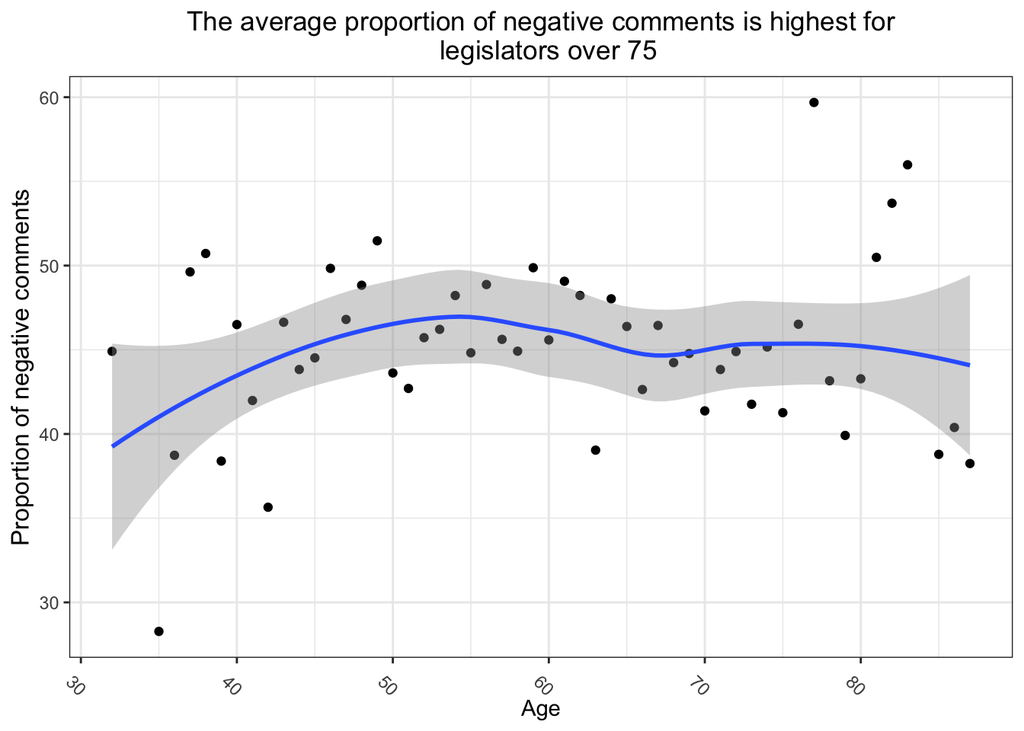

```r
# Calculate proportion of negative comments by age
df_congress_avg <- df_congress_age %>%
  group_by(age) %>%
  summarise(avg_pct_neg = mean(pct_neg))

ggplot(data = df_congress_avg, aes(x = age, y = avg_pct_neg)) +
  geom_point() +
  stat_smooth() +
  ggtitle("The average proportion of negative comments is highest for\
  legislators over 75") +
  ylab("Proportion of negative comments") +
  xlab("Age") +
  theme_bw() +
  theme(
    plot.title = element_text(hjust = 0.5),
    axis.title.y = element_text(size = 12),
    axis.text.x = element_text(angle = -45),
    legend.position = "bottom",
    legend.title = element_text(size = 10)
  )
```

3. The file `congress-list.csv` contained five other legislator-level variables (chamber, gender, party, ideology, state). Choose TWO of these variables and explore whether they are related with the extent to which Members of Congress receive negative comments on their Facebook pages. Write a summary of your findings.
- *I chose to explore the relationship between gender and party with the proportion of negative comments.*
- *Republican legislators, on average, received more negative comments than the other two parties, with Democrats receiving the lowest proportion of negative comments.*
- *Women had a lower proportion of negative comments than men.*
- *Surprisingly, the average proportion of negative comments is almost identical between genders within each party, with female legislators having a proportion of negative comments that is less than 0.5% higher than their male counterparts. (N.B. There are no female Independent legislators.)*

```r
df_addl_vars <- dbGetQuery(fbdb,
           "SELECT congress_list.facebook, everypol.age, AVG(CASE WHEN comments.sent_name == 'negative' THEN 1 ELSE 0 END)*100 as pct_neg,
           congress_list.gender, congress_list.party
           FROM congress_list
           JOIN everypol ON congress_list.bioguide_id = everypol.bioguide_id
           JOIN comments ON congress_list.facebook = comments.filename
           GROUP BY comments.filename")
# N.B.I downloaded the information in in a more general (i.e. less aggregated) form to be able to play with possible combinations / manipulations of the data as I created plots
```

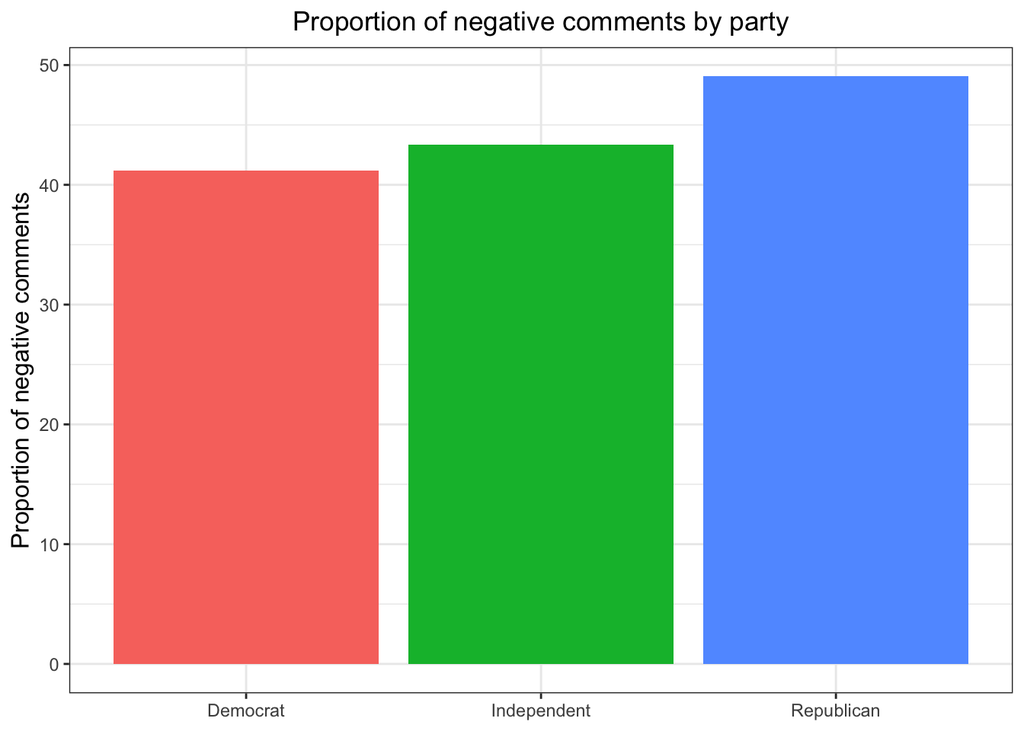

```r
df_addlvars_plot <- df_addl_vars %>%
  group_by(party) %>%
  summarise(avg_pct_neg = mean(pct_neg))

ggplot(data = df_addlvars_plot, aes(x = party, y = avg_pct_neg,
                                group = party,
                                fill = party)) +
  geom_bar(stat = "identity") +
  ggtitle("Proportion of negative comments by party") +
  ylab("Proportion of negative comments") +
  xlab("Party") +
  theme_bw() +
  theme(
    plot.title = element_text(hjust = 0.5),
    axis.title.y = element_text(size = 12),
    axis.title.x = element_blank(),
    legend.position = "none",
    legend.title = element_text(size = 10)
  )
```

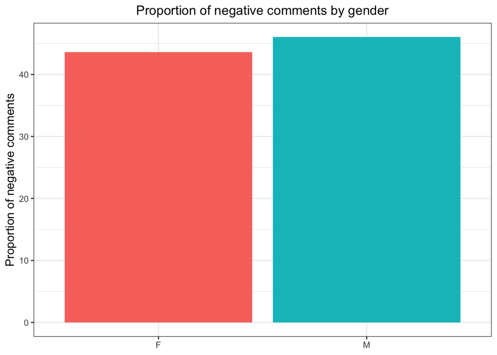

```r
df_addlvars_plot <- df_addl_vars %>%
  group_by(gender) %>%
  summarise(avg_pct_neg = mean(pct_neg))

ggplot(data = df_addlvars_plot, aes(x = gender, y = avg_pct_neg,
                                group = gender,
                                fill = gender)) +
  geom_bar(stat = "identity") +
  ggtitle("Proportion of negative comments by gender") +
  ylab("Proportion of negative comments") +
  xlab("Gender") +
  theme_bw() +
  theme(
    plot.title = element_text(hjust = 0.5),
    axis.title.y = element_text(size = 12),
    axis.title.x = element_blank(),
    legend.position = "none",
    legend.title = element_text(size = 10)
  )
```

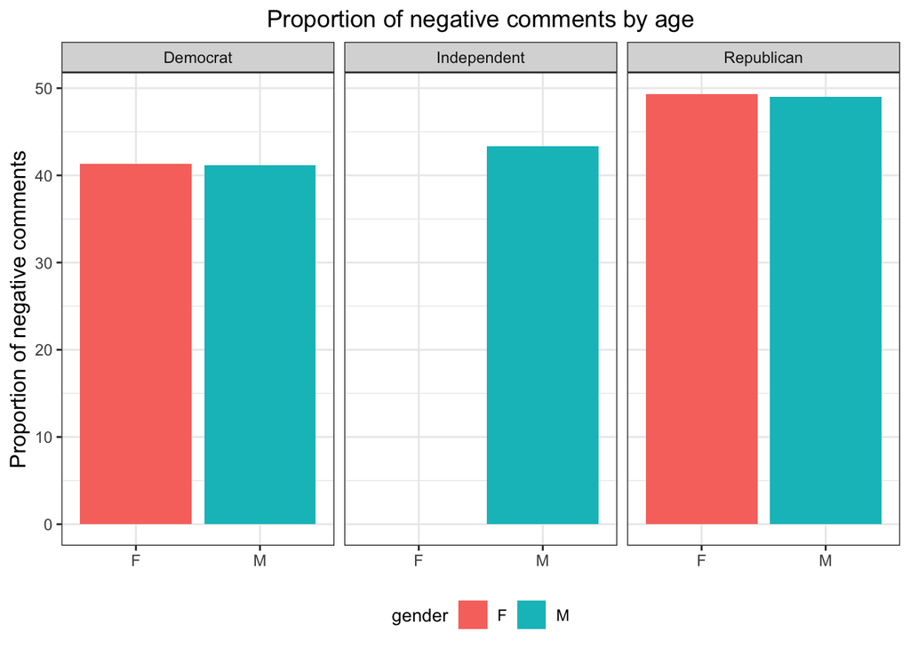

```r
df_addlvars_plot <- df_addl_vars %>%
  group_by(party, gender) %>%
  summarise(avg_pct_neg = mean(pct_neg))

ggplot(data = df_addlvars_plot, aes(x = gender, y = avg_pct_neg,
                                group = party,
                                fill = gender)) +
  geom_bar(stat = "identity") +
  facet_wrap(~ party, ncol = 3) +
  ggtitle("Proportion of negative comments by age") +
  ylab("Proportion of negative comments") +
  xlab("Age") +
  theme_bw() +
  theme(
    plot.title = element_text(hjust = 0.5),
    axis.title.y = element_text(size = 12),
    axis.title.x = element_blank(),
    legend.position = "bottom",
    legend.title = element_text(size = 10)
  )
```

```r
# Close connection
dbDisconnect(fbdb)
```